# Portfolio Development with SP500 Securities Using Applied Financial Mathematics

Mark Preston

March 23, 2019

## Part 1: Efficient Frontier, CAPM, and Market-Neutral Portfolio Construction using SP500 Stocks

For the final assignment, I’ll be working through a portfolio construction analysis using various financial analytics methods. For this, I’ll be using an assortment of nearly 300 SP 500 stocks from 2014. Beginning the analysis, I’ve loaded the necessary stock data and transformed the date column. The first five rows with the first five columns are shown below. In addition to individual securities, the data also contains the SP 500 index and the fed fund rate, which will be used as the risk-free rate.

```r
library(broom)
library(ggfortify)
library(urca)
library(fArma)
library(tidyverse)
library(kableExtra)
library(knitr)

#setting prefered ggplot theme
theme_set(
  theme_minimal()
)

#custom table function used throughout analysis
custom_kable <- function(x){
  kable(x, format = "html") %>%
    kable_styling(bootstrap_options = "striped")
}

sp500_2014 <- read.csv("SP500_Stocks_Portfolio.csv") %>%
  mutate(Date = as.Date(Date, origin = "1899-12-30"))

sp500_2014 %>%
  select(1:5) %>%
  head() %>%
  custom_kable()
```

| Date | SPY | FFRate | MS | WMB |
| --- | --- | --- | --- | --- |
| 2014-01-02 | 176.8325 | 0.08 | 30.36528 | 35.86406 |
| 2014-01-03 | 176.8035 | 0.08 | 30.83500 | 35.62983 |
| 2014-01-06 | 176.2912 | 0.08 | 30.94265 | 35.97649 |
| 2014-01-07 | 177.3739 | 0.07 | 30.84479 | 36.54798 |
| 2014-01-08 | 177.4126 | 0.07 | 30.88393 | 36.68852 |
| 2014-01-09 | 177.5286 | 0.07 | 30.87414 | 36.77284 |

### Efficient Frontier

With the data prepared, the efficient frontier work can proceed. The goal of this analysis is to develop a tool for portfolio management as it provides the expected return (mean) and risk or volatility (standard deviation) for a collection of securities. When plotting the returns against the volatility, a security’s risk-reward trade-off can be reviewed.

#### Calculate means and standard deviations of daily log-returns for each company and the SP index. Include the Fed Fund mean as well

As part of this, I’ve developed the mean (expected return) and standard deviation (volatility or risk) for each security. This calculation is done using the differenced log returns. The output preview can be seen below.

```r
fed_mean <- mean(sp500_2014$FFRate) / 100 / 250

stock_mean_sd <- data.frame(
  stock_mean = apply(sp500_2014[,-c(1,3)], 2, function(x) mean(diff(log(x)))),
  stock_sd = apply(sp500_2014[,-c(1,3)], 2, function(x) sd(diff(log(x))))
) %>%
  rownames_to_column(var = "symbol") %>%
  add_case(symbol = "Fed", stock_mean = fed_mean, stock_sd = 0) %>%
  mutate(sector = case_when(
    symbol == "Fed" ~ "Fed",
    symbol == "SPY" ~ "SP500",
    symbol != "Fed" | symbol != "SPY"~ "Stock"
  )
) %>%
  select(symbol, sector, everything())

stock_mean_sd %>%
  head() %>%
  custom_kable()
```

| symbol | sector | stock_mean | stock_sd |
| --- | --- | --- | --- |
| SPY | SP500 | 0.0005460 | 0.0070875 |
| MS | Stock | 0.0009411 | 0.0136474 |
| WMB | Stock | 0.0008074 | 0.0184858 |
| SNA | Stock | 0.0009888 | 0.0119090 |
| AMZN | Stock | -0.0009987 | 0.0207845 |
| DAL | Stock | 0.0023390 | 0.0210101 |

#### Plot the SPY companies on standard deviation-mean diagram to observe the efficient frontier. Add the points for SPY and risk-free rate while adding the Capital Allocation Line connecting the points of risk-free rate and SPY. Also add efficient frontier tagent.

Below, I’ve constructed the efficient frontier visualization. The scatter plot shows the securities mean and standard deviations, which makes the parabolic efficient frontier shape. To highlight this more, I’ve included its tangent line (coloured gold). The point that the line passes through is KR (Kroger Co), a large supermarket and general retailer.

#### Why is the point representing SPY located at the tip of the frontier?

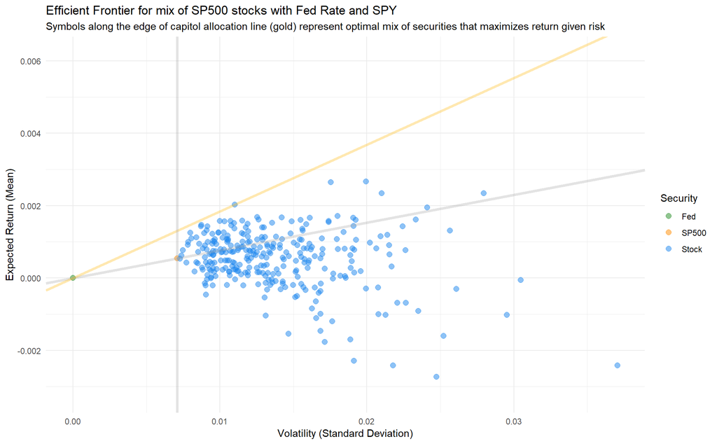

```r
spy_fed_slope <- stock_mean_sd %>%
  filter(symbol %in% c("SPY", "Fed")) %>%
  lm(stock_mean ~ stock_sd, data = .) %>%
  coefficients() %>%
  as.data.frame() %>%
  slice(-1)

kr_fed_slope <- stock_mean_sd %>%
  filter(symbol %in% c("KR", "Fed")) %>%
  lm(stock_mean ~ stock_sd, data = .) %>%
  coefficients() %>%
  as.data.frame() %>%
  slice(-1)

stock_mean_sd %>%
    ggplot(aes(stock_sd, stock_mean, colour = sector)) +
    geom_jitter(size = 2.5, alpha = .5) +
    geom_abline(slope = spy_fed_slope$.[1],
                intercept = 0, colour = "darkgray", size = 1.3, alpha = .33) +
    geom_abline(slope = kr_fed_slope$.[1],
                intercept = 0, colour = "darkgoldenrod1", size = 1.3, alpha = .33) +
    geom_vline(xintercept = stock_mean_sd$stock_sd[stock_mean_sd$symbol == "SPY"],
               colour = "darkgray", size = 1.3, alpha = .33) +
    scale_y_continuous(expand = c(0, .001, 0, .004)) +
    scale_colour_manual(values = c("forestgreen", "darkorange", "dodgerblue2")) +
    labs(title = "Efficient Frontier for mix of SP500 stocks with Fed Rate and SPY",
         subtitle = "Symbols along the edge of capitol allocation line (gold) represent optimal mix of securities that maximizes return given risk",
         x = "Volatility (Standard Deviation)",
         y = "Expected Return (Mean)",
         colour = "Security")
```

Just to reemphasize this point, I’ve arranged the securities in the set by lowest standard deviation. As expected, the Fed and SPY rates have the two lowest volatilities.

```r
stock_mean_sd %>%
  arrange(stock_sd) %>%
  slice(1:5) %>%
  custom_kable()
```

| symbol | sector | stock_mean | stock_sd |
| --- | --- | --- | --- |
| Fed | Fed | 0.0000036 | 0.0000000 |
| SPY | SP500 | 0.0005460 | 0.0070875 |
| SRCL | Stock | 0.0005298 | 0.0072920 |
| PG | Stock | 0.0006192 | 0.0073675 |
| TRV | Stock | 0.0007732 | 0.0074703 |

#### Plot cumulative returns of SPY and the tangent line stock. Create portfolio for the risk free investment and KR that has the same risk as SPY.

As seen below, I’ve developed a plot with the mixed portfolio. The mixture weight is derived by dividing the standard deviation from SPY with the standard deviation from KR. This weight is then used to develop the mixed portfolio where the Fed mean and KR are combined. As seen, the cumulative returns here are broadly between KR and SPY.

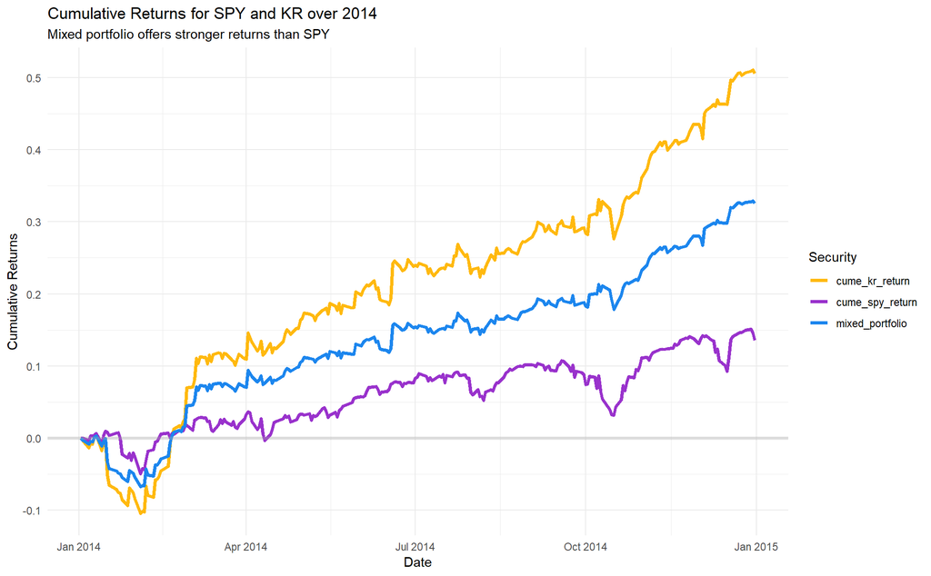

```r
kr_mixed_weight <- stock_mean_sd %>%
  filter(symbol %in% c("SPY", "KR")) %>%
  summarise(value = stock_sd[1] / stock_sd[2])

mixed_kr_portfolio <- (1 - kr_mixed_weight$value) *
  rep(fed_mean, length(sp500_2014[,1])) + kr_mixed_weight$value *
  c(0, diff(log(sp500_2014$KR)))

mixed_portfolio <- sp500_2014 %>%
  select(Date, SPY, KR) %>%
  mutate_at(vars(-Date), function(x) c(0, diff(log(x)))) %>%
  mutate(cume_spy_return = cumsum(SPY),
         cume_kr_return = cumsum(KR),
         mixed_portfolio =  cumsum(mixed_kr_portfolio)) %>%
  select(-KR, -SPY) %>%
  gather(key = "Security", value = "cume_return", -Date)

mixed_portfolio %>%
  ggplot(aes(Date, cume_return, colour = Security)) +
  geom_line(size = 1.3) +
  geom_hline(yintercept = 0, colour = "darkgray", size = 1.3, alpha = .33) +
  scale_y_continuous(breaks = seq(-1, 1, .1)) +
  scale_colour_manual(values = c("darkgoldenrod1", "darkorchid", "dodgerblue2")) +
  labs(title = "Cumulative Returns for SPY and KR over 2014",
       subtitle = "Mixed portfolio offers stronger returns than SPY",
       y = "Cumulative Returns")
```

This mixture ensures that the new portfolio has the same risk as SPY, which can be seen in the comparison table below.

```r
data.frame(
  portfolio = c("SPY", "Mixed"),
  risk = c(
    sd(diff(log(sp500_2014$SPY))),
    sd(mixed_kr_portfolio)
  )
) %>% custom_kable()
```

| portfolio | risk |
| --- | --- |
| SPY | 0.0070875 |
| Mixed | 0.0070737 |

### Capital Asset Pricing Model (CAPM)

CAPM is a modelling technique that produces a regression coefficient (beta) that measures how much risk a security adds to a portfolio. If the security is riskier than the market, it will have a beta greater than 1, and vice versa. This means a portfolio can be diversified to reduce risk. Picking up these dynamics means that CAPM is used as a portfolio optimization tool. The output here highlights each symbol has a beta, or slope coefficient, which captures its risk relative the market index.

```r
fed_rates_daily <- (sp500_2014$FFRate / 100 / 365)[1:249]

company_log_betas <- sp500_2014 %>%
  select(-1, -3) %>%
  mutate_all(function(x) c(0, diff(log(x)))) %>%
  slice(-1) %>%
  apply(., 2,
        function(z) lm(I(z - fed_rates_daily) ~ -1 +                                     I(diff(log(sp500_2014$SPY))- fed_rates_daily))$coefficients
    ) %>%
  as.data.frame() %>%
  rownames_to_column(var = "symbol") %>%
  select(symbol, beta = ".")

company_log_betas <- stock_mean_sd %>%
  select(-stock_sd) %>%
  left_join(x =. , y = company_log_betas, by = "symbol") %>%
  mutate_all(function(x) ifelse(is.na(x), 0, x))

company_log_betas %>%
  head() %>%
  custom_kable()
```

| symbol | sector | stock_mean | beta |
| --- | --- | --- | --- |
| SPY | SP500 | 0.0005460 | 1.000000 |
| MS | Stock | 0.0009411 | 1.318698 |
| WMB | Stock | 0.0008074 | 1.161078 |
| SNA | Stock | 0.0009888 | 1.174846 |
| AMZN | Stock | -0.0009987 | 1.466239 |
| DAL | Stock | 0.0023390 | 1.616292 |

To better highlight the betas, I’ve plotted them below. The collection of betas seems higher than the line as a guess, which would indicate these are slightly above average for risk when compared to the market index. Additionally, each beta also provides an estimate of the security’s excess log returns to the SPY excess log return.

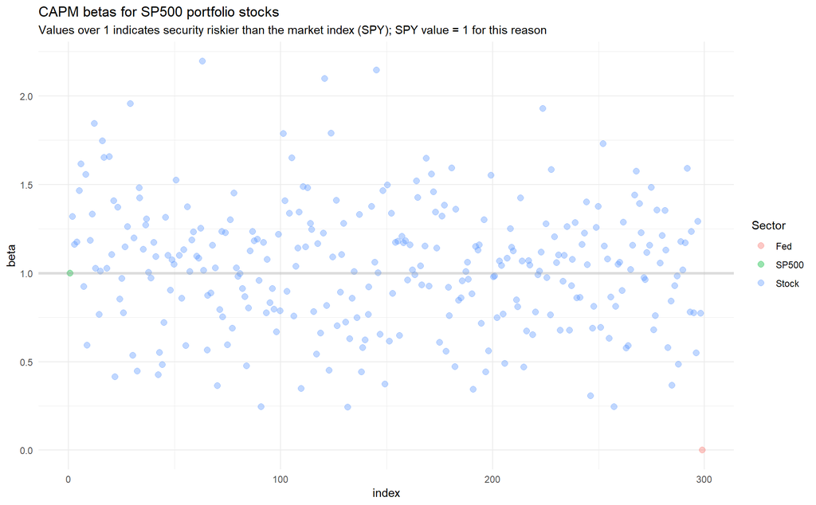

```r
company_log_betas %>%
  mutate(index = row_number()) %>%
  ggplot(aes(index, beta, colour = sector)) +
  geom_jitter(size = 2.5, alpha = .4) +
  geom_hline(yintercept = 1, colour = "darkgray", size = 1.3, alpha = .33) +
  labs(title = "CAPM betas for SP500 portfolio stocks",
       subtitle = "Values over 1 indicates security riskier than the market index (SPY); SPY value = 1 for this reason",
       colour = "Sector")
```

#### Select stocks Coca-Cola (KO), Plum Creek Timber (PCL) and Kroger (KR). Find their betas.

I’ve isolated the betas for the three select companies below. Each shows a beta value less than 1, indicating that these have slightly less volatility when the market is moving.

```r
company_log_betas %>%
  filter(symbol %in% c("KR", "KO", "PCL")) %>%
  custom_kable()
```

| symbol | sector | stock_mean | beta |
| --- | --- | --- | --- |
| KR | Stock | 0.0020318 | 0.7235475 |
| PCL | Stock | -0.0001476 | 0.5614330 |
| KO | Stock | 0.0002698 | 0.4688352 |

#### Create plot for the Betas-Mean Return space. According to the CAPM model, which of the selected stocks should have been bought in 2014 and which should have been shorted?

The CAPM visualization can be seen below where the company betas are in a scatter plot against the returns. The gray line is again the adjusted risk-free line, which means companies below are overvalued because they add more risk while not maintaining market returns. This means that they are overvalued. Conversely, the securities above are undervalued. Using this criteria, not all of the three selected stocks appear above the line. Both KO (Coca-Cola) and KR (Kroger) do though, although Coke is essentially on the line suggesting it’s priced reasonably fair. For a long portfolio, Kroger would be the most appropriate choice. On the other side, PCL (Plum Creek Timber) is overvalued and as such, I wouldn’t have purchased it. This would be the most ideal short candidate from the three selected stocks.

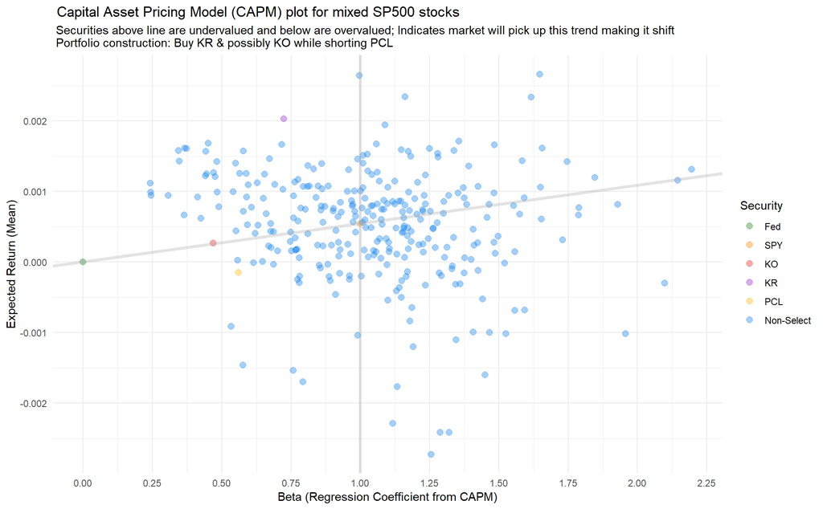

```r
spy_fed_slope_capm <- company_log_betas %>%
  filter(symbol %in% c("SPY", "Fed")) %>%
  lm(stock_mean ~ beta, data = .) %>%
  coefficients() %>%
  as.data.frame() %>%
  slice(-1)

company_log_betas %>%
  mutate(select_stock = case_when(
    symbol == "KR" ~ "KR",
    symbol == "KO" ~ "KO",
    symbol == "PCL" ~ "PCL",
    symbol == "SPY" ~ "SPY",
    symbol == "Fed" ~ "Fed",
    !symbol %in% c("KR", "KO", "PCL", "SPY", "Fed") ~ "Non-Select"
  )
) %>%
  mutate(select_stock = factor(select_stock, levels = c("Fed", "SPY",
                                                        "KO", "KR",
                                                        "PCL", "Non-Select"))) %>%
  ggplot(aes(beta, stock_mean, colour = select_stock)) +
  geom_jitter(size = 2.5, alpha = .4) +
  geom_abline(slope = spy_fed_slope_capm$.,
              intercept = company_log_betas$stock_mean[stock_mean_sd$symbol == "Fed"],
              colour = "darkgray", size = 1.3, alpha = .33) +
  scale_x_continuous(breaks = seq(0, 3, .25)) +
  geom_vline(xintercept = 1, colour = "darkgray", size = 1.3, alpha = .33) +
  scale_colour_manual(values = c("forestgreen", "darkorange", "firebrick2",
                                 "darkorchid", "darkgoldenrod1", "dodgerblue2")) +
  labs(title = " Capital Asset Pricing Model (CAPM) plot for mixed SP500 stocks",
       subtitle = " Securities above line are undervalued and below are overvalued; Indicates market will pick up this trend making it shift \n Portfolio construction: Buy KR & possibly KO while shorting PCL",
       x = "Beta (Regression Coefficient from CAPM)",
       y = "Expected Return (Mean)",
       colour = "Security")
```

#### Market-Neutral Portfolio

Creating a market neutral portfolio can be done if it has a mixture of long and short positions that are equal when developed or, periodically maintained to be equal. This portfolio weighting can be developed by taking an initial value capturing the long to short ratio. Below, using the selected stocks, I’ve done this using PCL and KR. The value suggests that to construct the market neutral portfolio, for each PCL share shorted there should be 2.24 KR purchased.

```r
long_portfolio_weight <- sp500_2014$PCL[1] / sp500_2014$KR[1]

data.frame(
  weight_type = "long weight",
  value = long_portfolio_weight
  ) %>%
  custom_kable()
```

| weight_type | value |
| --- | --- |
| long weight | 2.240926 |

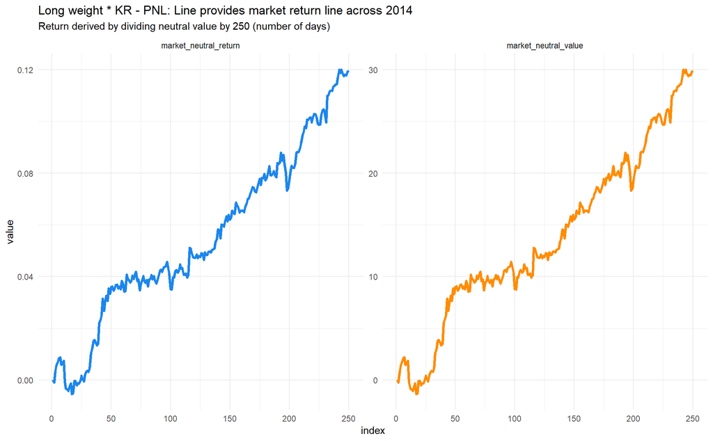

```r
sp500_2014 %>%
  mutate(market_neutral_value = long_portfolio_weight * KR - PCL,
         market_neutral_return = market_neutral_value / 250,
         index = row_number()) %>%
  select(market_neutral_value, market_neutral_return, index) %>%
  gather(key = "series", value = "value", -index) %>%
  ggplot(aes(index, value, colour = series)) +
  geom_line(size = 1.3, show.legend = F) +
  scale_colour_manual(values = c("dodgerblue2", "darkorange")) +
  facet_wrap(facets = "series", scales = "free") +
  labs(title = "Long weight * KR - PNL: Line provides market return line across 2014",
       subtitle = "Return derived by dividing neutral value by 250 (number of days)")
```

#### Create market-neutral portfolio of stocks according to the CAPM starting at the beginning of 2014 and track its value for the rest of the year

To accomplish this, the first step is deriving the intercept and slope for the Security Market Line. The intercept here is the fed mean while the slope comes from the difference between the SPY point and fed mean. I’ve also developed an SML function, which just contains the standard regression equation. With both of these created, the line can be created by providing the security betas to the x parameter, similar to a prediction task in a normal regression model. This creates the SML values.

These values are essential to developing the portfolio, as seen in the visualization below. Essentially, the difference between the stock mean and the SML value for the security (the residual) marks whether a stock is long or short. The variable I’ve added here captures this relationship: if a residual is positive, or above the line, it receives a long label while negative values become short. With this, the portfolio construction can begin to take shape.

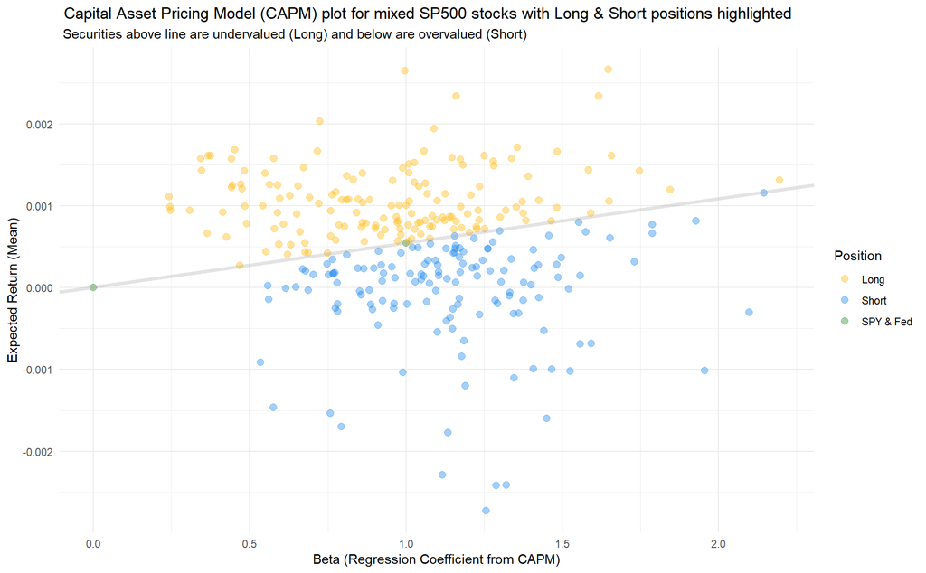

```r
capm_slope_data <- data.frame(
  a = fed_mean,
  b = stock_mean_sd$stock_mean[1] - fed_mean
  )

sml <- function(a, b, x){
  a + b * x
}

company_log_betas <- company_log_betas %>%
  mutate(sml = sml(a = capm_slope_data$a, b = capm_slope_data$b, x = beta),
         portfolio_position = case_when(
           stock_mean - sml >= 0 ~ "Long",
           stock_mean - sml <= 0 ~ "Short"),
         portfolio_position = ifelse(symbol %in% c("Fed", "SPY"),
                                     "SPY & Fed", portfolio_position))

company_log_betas %>%
  ggplot(aes(beta, stock_mean, colour = portfolio_position)) +
  geom_jitter(size = 2.5, alpha = .4) +
  geom_abline(slope = capm_slope_data$b,
              intercept = capm_slope_data$a,
              colour = "darkgray", size = 1.3, alpha = .33) +
  scale_colour_manual(values = c("darkgoldenrod1", "dodgerblue2", "forestgreen")) +
    labs(title = " Capital Asset Pricing Model (CAPM) plot for mixed SP500 stocks with Long & Short positions highlighted",
       subtitle = " Securities above line are undervalued (Long) and below are overvalued (Short)",
       x = "Beta (Regression Coefficient from CAPM)",
       y = "Expected Return (Mean)",
       colour = "Position")
```

The long and short development follows a very similar pattern so to standardize the coding, I’ve developed a function that finds the weights, plots them, and also returns the portfolio weight value so each side can be compared. Below, I’ve formalized the long selection by filtering the initial position label. As a methodological note, the weights are just each individual security residual divided by the sum of total residuals. The first five rows of these are shown.

```r
portfolio_weight_dev <- function(data, position){
  weights <- data %>%
    filter(portfolio_position == position) %>%
    mutate(mal_distance = stock_mean - sml,
           weight = mal_distance / sum(mal_distance))

  weight_plot <- weights %>%
    mutate(index = row_number()) %>%
    ggplot(aes(index, weight)) +
    geom_line(size = 1.3, colour = "dodgerblue2") +
    labs(title = paste(position, "weight plot for portfolio construction"),
         subtitle = paste("All portfolio weights sum =", sum(weights$weight)))

  portfolio_symbols <- weights$symbol

  weighted_value <- as.matrix(sp500_2014[1,-(1:3)])[,portfolio_symbols] %*%
    weights$weight %>% as.numeric()

  output <- list(weights = weights,
                 weight_plot = weight_plot,
                 weighted_value = weighted_value)

  return(output)

}

long_only_weights <- portfolio_weight_dev(data = company_log_betas,
                                          position = "Long")

long_only_weights$weights %>%
  head() %>%
  custom_kable()
```

| symbol | sector | stock_mean | beta | sml | portfolio_position | mal_distance | weight |
| --- | --- | --- | --- | --- | --- | --- | --- |
| MS | Stock | 0.0009411 | 1.318698 | 0.0007188 | Long | 0.0002223 | 0.0025716 |
| WMB | Stock | 0.0008074 | 1.161078 | 0.0006333 | Long | 0.0001740 | 0.0020130 |
| SNA | Stock | 0.0009888 | 1.174846 | 0.0006408 | Long | 0.0003480 | 0.0040251 |
| DAL | Stock | 0.0023390 | 1.616292 | 0.0008802 | Long | 0.0014588 | 0.0168734 |
| SRCL | Stock | 0.0005298 | 0.593475 | 0.0003255 | Long | 0.0002043 | 0.0023636 |
| HAR | Stock | 0.0011951 | 1.845430 | 0.0010045 | Long | 0.0001906 | 0.0022049 |

The plot shows how variable the weights are. Higher values indicate further distance from the line meaning they are the most undervalued. Weights towards zero are more in line with fair evaluation; KO (Coke) would be amongst this group given the previous work.

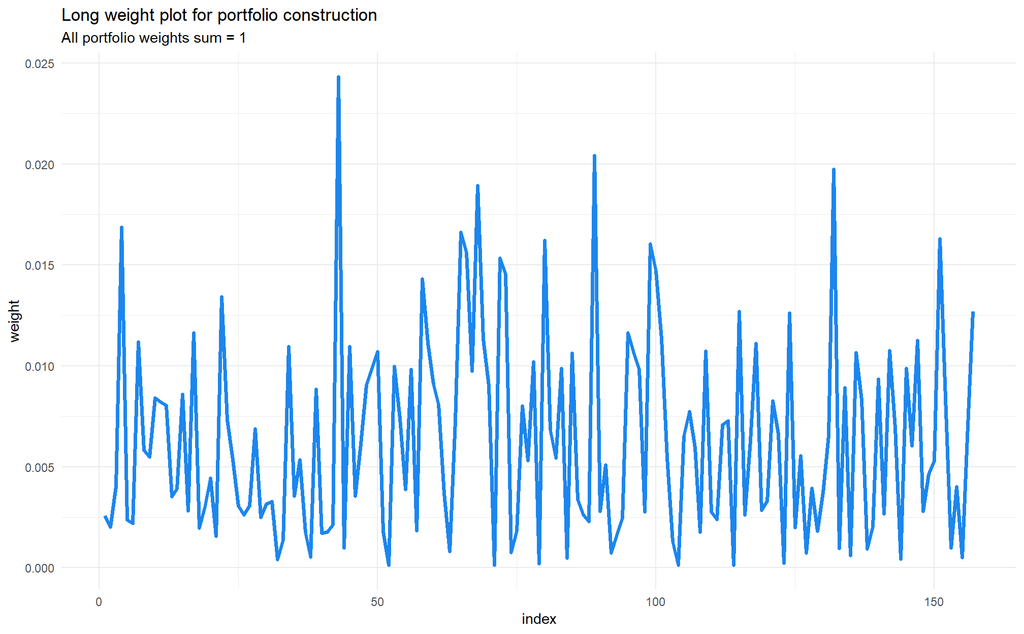

```r
long_only_weights$weight_plot
```

Switching to the short position, I’m following the same basic approach here by using the customized function to derive the necessary objects. The first five short position securities are shown below.

```r
short_only_weights <- portfolio_weight_dev(data = company_log_betas,
                                           position = "Short")

short_only_weights$weights %>%
  head() %>%
  custom_kable()
```

| symbol | sector | stock_mean | beta | sml | portfolio_position | mal_distance | weight |
| --- | --- | --- | --- | --- | --- | --- | --- |
| AMZN | Stock | -0.0009987 | 1.4662390 | 0.0007988 | Short | -0.0017975 | 0.0182748 |
| PX | Stock | 0.0000816 | 0.9234804 | 0.0005045 | Short | -0.0004229 | 0.0042992 |
| HP | Stock | -0.0006869 | 1.5568654 | 0.0008480 | Short | -0.0015349 | 0.0156049 |
| AIG | Stock | 0.0004365 | 1.1835709 | 0.0006455 | Short | -0.0002090 | 0.0021251 |
| BBY | Stock | -0.0000589 | 1.3321213 | 0.0007261 | Short | -0.0007850 | 0.0079811 |
| BAX | Stock | 0.0003448 | 0.7656391 | 0.0004188 | Short | -0.0000741 | 0.0007530 |

The same criteria holds here where weights closer to zero are nearer to the SML while larger weights are further away.

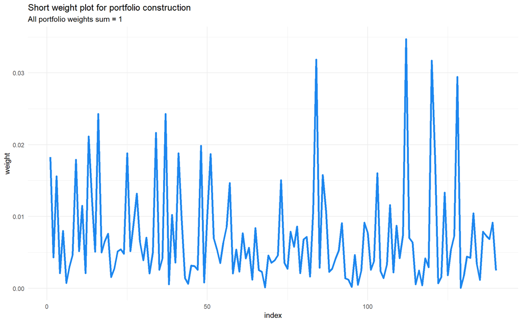

```r
short_only_weights$weight_plot
```

Putting both portfolio positions together, the weights for Long and Short displayed here. The proportion indicates that for every 1 share from the short side there should be about 1.284 shares being purchased for long.

```r
weights_and_proportions <- data.frame(
  portfolio = c("Long", "Short", "Proportion"),
  weight_value = c(long_only_weights$weighted_value,
                   short_only_weights$weighted_value,
                   short_only_weights$weighted_value /
                     long_only_weights$weighted_value)
)

weights_and_proportions %>%
  custom_kable()
```

| portfolio | weight_value |
| --- | --- |
| Long | 63.472422 |
| Short | 81.490772 |
| Proportion | 1.283877 |

#### How would you calculate the annual return of this portfolio?

I’ve plotted both series below. The total trajectory line can be interpreted as the portfolio returns accruing across the year. The rolling returns can be found by dividing the total trajectory values by 250, which makes them daily values.

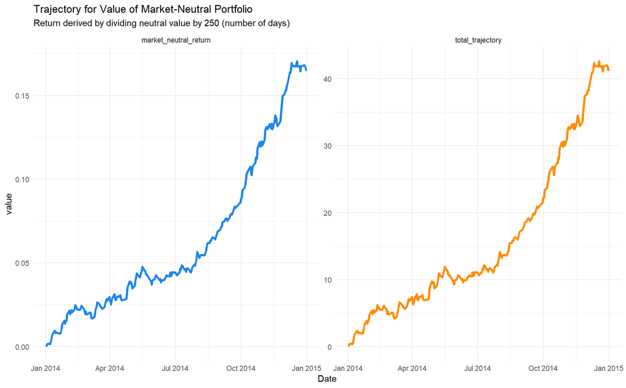

```r
long_symbols <- long_only_weights$weights$symbol

short_symbols <- short_only_weights$weights$symbol

data.frame(
  long_trajectory = as.matrix(sp500_2014[,-(1:3)])[,long_symbols] %*%
    long_only_weights$weights$weight,
  short_trajectory = as.matrix(sp500_2014[,-(1:3)])[,short_symbols] %*%
    short_only_weights$weights$weight
) %>%
  mutate(Date = sp500_2014$Date,
         total_trajectory = t(weights_and_proportions$weight_value[3] %*%
           long_trajectory - short_trajectory) %>% as.numeric(),
         market_neutral_return = total_trajectory / 250) %>%
  select(Date, total_trajectory, market_neutral_return) %>%
  gather(key = "series", value = "value", -Date) %>%
  ggplot(aes(Date, value, colour = series)) +
  geom_line(size = 1.3, show.legend = F) +
  scale_colour_manual(values = c("dodgerblue2", "darkorange")) +
  facet_wrap(facets = "series", scales = "free") +
  labs(title = "Trajectory for Value of Market-Neutral Portfolio",
       subtitle = "Return derived by dividing neutral value by 250 (number of days)")
```

## Part 2: Arbitrage Pricing Theory and Market-Neutral Portfolio

Starting the second part, I still have the same SP500 data loaded but, APT requires having all the each column be log differenced. For this, I’ve also dropped the Date, SPY, and Fed fund columns.

```r
portfolio_returns <- sp500_2014 %>%
  select(-Date, - SPY, -FFRate) %>%
  mutate_all(function(x) c(0, diff(log(x)))) %>%
  slice(-1)

portfolio_returns %>%
  select(1:5) %>%
  head() %>%
  custom_kable()
```

| MS | WMB | SNA | AMZN | DAL |
| --- | --- | --- | --- | --- |
| 0.0153505 | -0.0065522 | 0.0019327 | -0.0038519 | 0.0537631 |
| 0.0034849 | 0.0096822 | -0.0104442 | -0.0071133 | 0.0020506 |
| -0.0031676 | 0.0157605 | 0.0023201 | 0.0111160 | -0.0175655 |
| 0.0012682 | 0.0038378 | -0.0011129 | 0.0097257 | 0.0348276 |
| -0.0003169 | 0.0022956 | -0.0024157 | -0.0022667 | 0.0414124 |
| -0.0079555 | 0.0025445 | 0.0002790 | -0.0083890 | 0.0131139 |

APT is a more complex modelling approach than CAPM. These are linear models that attempt to predict asset return while considering macroeconomic variables. In this case, theses outside variables will be estimated using the factor scores from a PCA on the SP stocks. As such, I’ve used `prcomp` below to do eigenvalue decomposition on the stock portfolio.

#### Factor Selection

The factors here are derived using PCA,

```r
returns_pca <- prcomp(x = portfolio_returns)
```

An initial summary for the first ten principle components shows that PC1 explains about 30% of the set variance with diminishing explanations thereafter. All ten explain about 52% of variance in the set. This sets up that depending on the number of components picked going forward, there will be different variance explanations in the modelling work.

```r
pca_variance <- summary(returns_pca)$importance[,1:10] %>%
  as.data.frame()

pca_variance %>%
  custom_kable()
```

|  | PC1 | PC2 | PC3 | PC4 | PC5 | PC6 | PC7 | PC8 | PC9 | PC10 |
| --- | --- | --- | --- | --- | --- | --- | --- | --- | --- | --- |
| Standard deviation | 0.1372917 | 0.0603921 | 0.0455692 | 0.0412955 | 0.0382735 | 0.0331408 | 0.031883 | 0.030204 | 0.0299192 | 0.0291895 |
| Proportion of Variance | 0.3002800 | 0.0581000 | 0.0330800 | 0.0271700 | 0.0233400 | 0.0175000 | 0.016190 | 0.014530 | 0.0142600 | 0.0135700 |
| Cumulative Proportion | 0.3002800 | 0.3583800 | 0.3914600 | 0.4186300 | 0.4419700 | 0.4594600 | 0.475660 | 0.490190 | 0.5044500 | 0.5180300 |

The factor loadings are of interest here as well. These are the eigenvector matrix for the set, the dimensions of which can be seen below. When converting the initial SP500 log differenced returns to factor scores, the eigencvector matrix is multiplied with the set. Additionally, the loadings provide insight into what information from the initial set is being carried in each principle component.

```r
data.frame(
  dimension = c("rows", "columns"),
  values = c(dim(returns_pca$rotation)[1], dim(returns_pca$rotation)[2])
) %>% custom_kable()
```

| dimension | values |
| --- | --- |
| rows | 297 |
| columns | 249 |

#### Create matrix of approximations of stock returns using a selected number of factors. Repeat analysis of approximations with several different numbers of selected factors.

To conduct this analysis, I’ve developed a function that takes the pca object and creates the return approximations. These are developed by multiplying the factor scores by the transposed factor loadings. The similarity between the approximations and returns can be estimated using a simple linear regression where the actual portfolio returns are the outcome variable. The subsequent $R^2$ describes how much variance the approximations explain. I’ve repeated the approximations with four different factor selections to highlight that adding more increases the model $R^2$. As seen by the first five rows, the variance explanations vary as much 37% by adding more factors (Amazon).

```r
return_approximation <- function(pca_object, factor_n, col){
  sp_factor_loadings <- pca_object$rotation[,1:factor_n]

  sp_factor_scores <- as.matrix(portfolio_returns) %*%
    as.matrix(sp_factor_loadings) %>%
    as.data.frame()

  return_approximations <- as.matrix(sp_factor_scores) %*% t(sp_factor_loadings) %>%
    as.data.frame()

  returns_lm <- lm(portfolio_returns[,col] ~ return_approximations[,col])
  R_sq <- summary(returns_lm)$r.squared

  output <- list(
    return_approx = return_approximations,
    Rsq = R_sq
  )

  return(output)
}

column_n <- seq(1, ncol(portfolio_returns), 1)

determination_coefs <- data.frame(
  stock = names(sp500_2014)[-1:-3],
  five_R2 = map_dbl(column_n, function(x)
    return_approximation(pca_object = returns_pca, factor_n = 5, col = x)$Rsq),
  ten_R2 = map_dbl(column_n, function(x)
    return_approximation(pca_object = returns_pca, factor_n = 10, col = x)$Rsq),
  fifteen_R2 = map_dbl(column_n, function(x)
    return_approximation(pca_object = returns_pca, factor_n = 15, col = x)$Rsq),
  twenty_R2 = map_dbl(column_n, function(x)
    return_approximation(pca_object = returns_pca, factor_n = 20, col = x)$Rsq)
)

determination_coefs %>%
  head() %>%
  custom_kable()
```

| stock | five_R2 | ten_R2 | fifteen_R2 | twenty_R2 |
| --- | --- | --- | --- | --- |
| MS | 0.5177520 | 0.5580644 | 0.5916609 | 0.6264961 |
| WMB | 0.3904305 | 0.4164145 | 0.4585676 | 0.4972740 |
| SNA | 0.5442143 | 0.5698139 | 0.6040597 | 0.6476656 |
| AMZN | 0.3270697 | 0.5021910 | 0.6438310 | 0.6952051 |
| DAL | 0.4208434 | 0.4479671 | 0.4842855 | 0.5347064 |
| PX | 0.5431318 | 0.5757345 | 0.5953528 | 0.6534773 |

#### What do you think about the quality of approximation? Is it consistent with the selected number of factors? What characteristic in the PCA output do you use in order to answer this question?

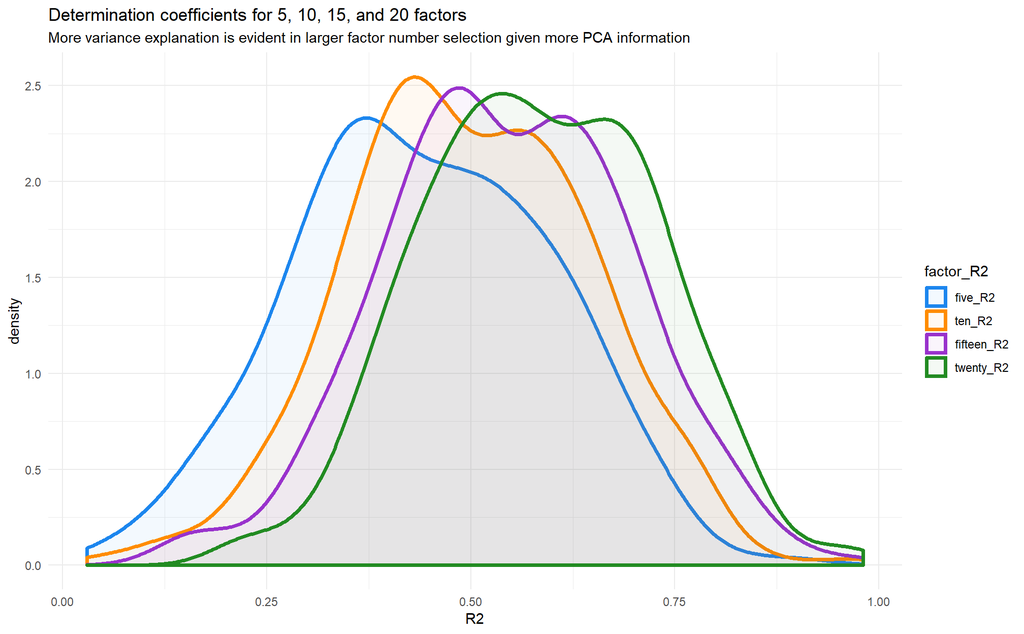

```r
factor_R2 <- determination_coefs %>%
  gather(key = "factor_R2", value = "R2", -stock) %>%
  mutate(factor_R2 = factor(factor_R2, levels = c("five_R2", "ten_R2",
                                                  "fifteen_R2", "twenty_R2")))

factor_R2 %>%
  ggplot(aes(R2, colour = factor_R2, fill = factor_R2)) +
  geom_density(size = 1.3, alpha = .05) +
  scale_y_continuous(breaks = seq(0, 3, .5)) +
  scale_colour_manual(values = c("dodgerblue2", "darkorange",
                                 "darkorchid", "forestgreen")) +
  scale_fill_manual(values = c("dodgerblue2", "darkorange",
                                 "darkorchid", "forestgreen")) +
  labs(title = "Determination coefficients for 5, 10, 15, and 20 factors",
       subtitle = "More variance explanation is evident in larger factor number selection given more PCA information")
```

This trend is evident in the average $R^2$ captured by the different factor numbers where adding more factors increases variance explanation.

```r
approx_means <- factor_R2 %>%
  group_by(factor_R2) %>%
  summarise(R2_mean = mean(R2))

approx_means %>%
  custom_kable()
```

| factor_R2 | R2_mean |
| --- | --- |
| five_R2 | 0.4409236 |
| ten_R2 | 0.4970762 |
| fifteen_R2 | 0.5439973 |
| twenty_R2 | 0.5836235 |

Focusing on ten factors specifically, the approximation seems reasonable. As I’ve mentioned the return approximation $R^2$ can be compared to the PCA variance capture to evaluate if these numbers are consistent. In this case, they only differ by a few points so I think the approximations are good.

[figure not shown]

```r
factor_R2 %>%
  filter(factor_R2 == "ten_R2") %>%
  ggplot(aes(R2)) +
  geom_density(size = 1.3, alpha = .05,
               colour = "dodgerblue2", fill = "dodgerblue2") +
  geom_vline(xintercept = pca_variance$PC10[3], colour = "darkorange", size = 1.3) +
  geom_vline(xintercept = approx_means$R2_mean[2], colour = "darkorchid", size = 1.3) +
  scale_y_continuous(breaks = seq(0, 3, .5)) +
  labs(title = "Five factor return approximations vs actual R2 density",
       subtitle = "Average R2 (purple line) is close to PCA variance capture (orange line); approximation seems reasonable")
```

#### Visualize approximations for several stocks

So far, I’ve only evaluated the approximations at a high level but, each security has an $R^2$ for the approximation vs actual linear model. To highlight this, I’ve randomly selected nine stocks to assess how close the approximations are to the actual returns. When visualized, these nine appear to have reasonable fits. Amongst this group, YUM seems to have the least correlation.

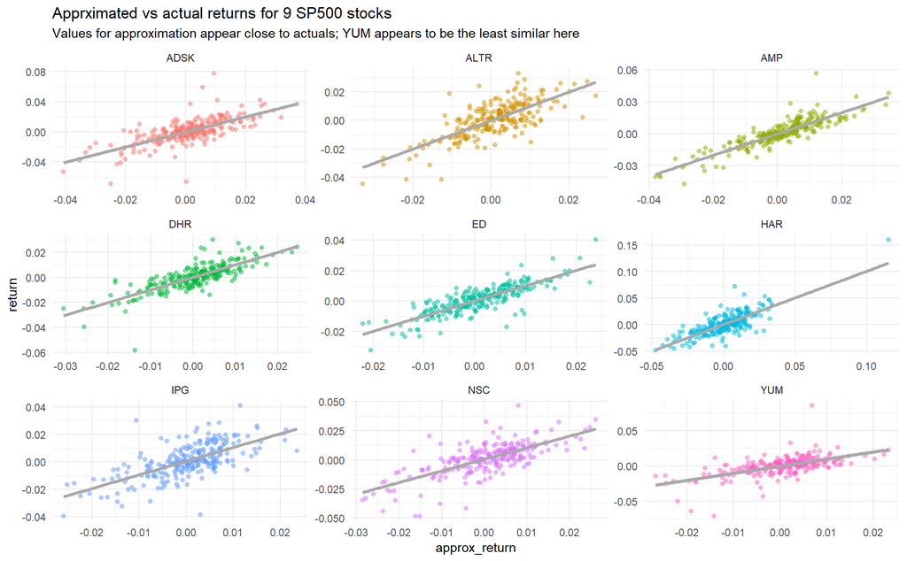

```r
set.seed(1017)
random_stocks <- sample(x = names(sp500_2014)[-1:-3], size = 9, replace = F)

return_approximation <- map(column_n, function(x)
  return_approximation(pca_object = returns_pca,
                       factor_n = 10,
                       col = x))

portfolio_returns %>%
  gather(key = "stock", value = "return") %>%
  bind_cols(
    return_approximation[[1]]$return_approx %>%
      gather(key = "stock", value = "approx_return") %>%
      select(-stock)
  ) %>%
  filter(stock %in% random_stocks) %>%
  ggplot(aes(approx_return, return, colour = stock)) +
  geom_point(show.legend = F, alpha = .5) +
  geom_smooth(method = "lm", se = F, size = 1.3, colour = "darkgray") +
  facet_wrap(facets = "stock", scales = "free") +
  labs(title = "Apprximated vs actual returns for 9 SP500 stocks",
       subtitle = "Values for approximation appear close to actuals; YUM appears to be the least similar here")
```

Confirming this, I’ve included the $R^2$ for each below. AMP has the highest value while YUM does indeed have the lowest.

```r
determination_coefs %>%
  select(stock,
         "R2" = ten_R2) %>%
  filter(stock %in% random_stocks) %>%
  arrange(desc(R2)) %>%
  custom_kable()
```

| stock | R2 |
| --- | --- |
| AMP | 0.7739996 |
| ED | 0.6840269 |
| DHR | 0.6264246 |
| HAR | 0.6233484 |
| ALTR | 0.5309741 |
| NSC | 0.5034464 |
| ADSK | 0.4950360 |
| IPG | 0.4394185 |
| YUM | 0.3510247 |

#### Beta Estimation

The market betas are the ten factor loadings from the returns pca. This is essentially a mix of market information from the 297 stocks compressed into ten loadings.

```r
market_betas <- returns_pca$rotation[,1:10] %>%
  as.data.frame() %>%
  rownames_to_column(var = "Stock") %>%
  mutate(Alpha = returns_pca$center %>% as.numeric()) %>%
  select(Stock, Alpha, everything())

market_betas %>%
  select(-Alpha) %>%
  head() %>%
  custom_kable()
```

| Stock | PC1 | PC2 | PC3 | PC4 | PC5 | PC6 | PC7 | PC8 | PC9 | PC10 |
| --- | --- | --- | --- | --- | --- | --- | --- | --- | --- | --- |
| MS | -0.0675903 | 0.0299511 | -0.0096139 | 0.0584286 | 0.0265979 | -0.0448650 | 0.0543062 | -0.0098258 | 0.0447955 | -0.0220773 |
| WMB | -0.0660234 | -0.1124398 | 0.0159579 | -0.0518203 | -0.0049775 | 0.0455247 | -0.0440126 | 0.0587266 | 0.0135532 | -0.0394093 |
| SNA | -0.0628534 | 0.0022006 | -0.0017246 | 0.0397013 | -0.0022317 | 0.0313406 | 0.0061204 | 0.0410813 | -0.0200850 | -0.0268233 |
| AMZN | -0.0775038 | 0.0600912 | -0.0744783 | -0.0087296 | 0.0471072 | 0.2006549 | -0.0132659 | 0.0636325 | -0.1148067 | 0.1360006 |
| DAL | -0.0818834 | 0.1250894 | -0.0311031 | -0.0119427 | 0.0068257 | -0.0590539 | -0.0279527 | -0.0007871 | -0.0784964 | 0.0463742 |
| PX | -0.0481062 | -0.0049145 | 0.0164568 | 0.0238247 | -0.0108548 | -0.0201640 | 0.0254943 | 0.0399088 | -0.0095685 | -0.0099125 |

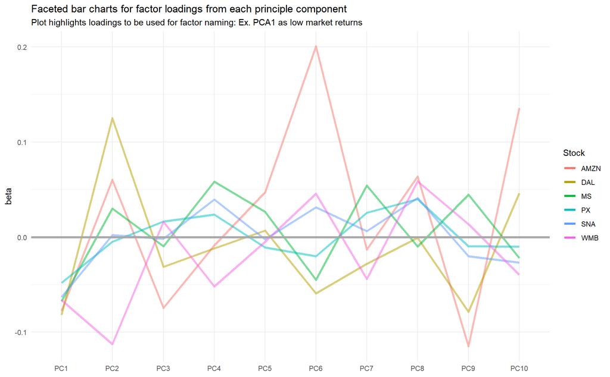

```r
gathered_betas <- market_betas %>%
  select(-Alpha) %>%
  slice(1:6) %>%
  gather(key = "factor", value = "beta", -Stock) %>%
  mutate(factor = factor(factor, levels = c(paste("PC", seq(1:10), sep = ""))))

gathered_betas %>%
  ggplot(aes(factor, beta, colour = Stock, group = Stock)) +
  geom_line(size = 1.3, alpha = .5) +
  guides(colour = guide_legend(override.aes = list(alpha = 1))) +
  geom_hline(yintercept = 0, size = 1.3, colour = "darkgray") +
  labs(title = "Faceted bar charts for factor loadings from each principle component",
   subtitle = "Plot highlights loadings to be used for factor naming: Ex. PCA1 as low market returns",
   x = NULL)
```

I think the line plot is slightly busy so I’ve also included a faceted bar chart. This clearly shows each stocks relationship to the loadings. Here, it looks like PCA8 could be general market uptick in contrast to market down in PC1.

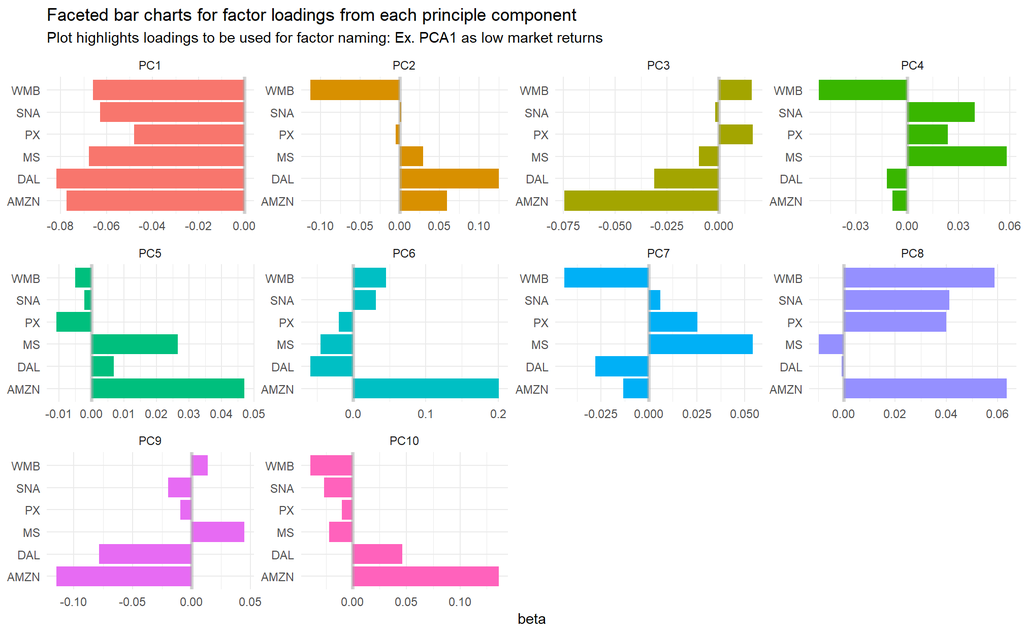

```r
gathered_betas %>%
  ggplot(aes(Stock, beta, fill = factor)) +
  geom_col(show.legend = F) +
  facet_wrap(facets = "factor", scales = "free") +
  coord_flip() +
  geom_hline(yintercept = 0, alpha = .5, size = 1.3, colour = "darkgray") +
  labs(title = "Faceted bar charts for factor loadings from each principle component",
     subtitle = "Plot highlights loadings to be used for factor naming: Ex. PCA1 as low market returns",
     x = NULL)
```

#### Estimation of market risk prices. Identify market prices of risk which are insignificant.

I’ve included a model to estimate the market price of risk. This is formally called the equilibrium equation for APT. To construct the model, I’ll be using the PCA centres from the initial principle component work. In practice, these are equal to the intercepts from a linear model with stock returns against all ten principle components. The model includes these pca centres minus the fed rate mean as the outcome with each security pca coefficient as the predictors. There are only two principle components that are not significant here (PCA6 & PCA8). Interestingly, I highlighted PCA8 as general market improvements but, it has high p-value so is insignificant in the model. The other eight principle components are all significant. The slope coefficients here represent the market price of risk.

```r
market_risk_price_lm <- lm(Alpha - fed_mean ~. -1,
                           data = market_betas[,-1])

tidy(market_risk_price_lm) %>%
  custom_kable()
```

| term | estimate | std.error | statistic | p.value |
| --- | --- | --- | --- | --- |
| PC1 | -0.0073009 | 0.0005804 | -12.5794805 | 0.0000000 |
| PC2 | 0.0083235 | 0.0005804 | 14.3414109 | 0.0000000 |
| PC3 | 0.0025701 | 0.0005804 | 4.4283201 | 0.0000135 |
| PC4 | -0.0029574 | 0.0005804 | -5.0956214 | 0.0000006 |
| PC5 | -0.0041024 | 0.0005804 | -7.0683858 | 0.0000000 |
| PC6 | -0.0002280 | 0.0005804 | -0.3928650 | 0.6947108 |
| PC7 | 0.0017325 | 0.0005804 | 2.9851451 | 0.0030786 |
| PC8 | -0.0003369 | 0.0005804 | -0.5803932 | 0.5621049 |
| PC9 | -0.0014996 | 0.0005804 | -2.5838431 | 0.0102651 |
| PC10 | -0.0032760 | 0.0005804 | -5.6445536 | 0.0000000 |

The model shows an adjusted $R^2$ of .6261, which denotes it explains about 63% of the variance in the outcome. The model F-test would also reject the utility hypothesis at a 5% level highlighting that there is a significant relationship between the alpha and PCA inputs.

```r
data.frame(
  metric = c("R2", "Adjusted R2", "F Stat"),
  value = c(
    summary(market_risk_price_lm)$r.squared,
    summary(market_risk_price_lm)$adj.r.squared,
    summary(market_risk_price_lm)$fstatistic[1]
  ) %>% round(4)
) %>% custom_kable()
```

| metric | value |
| --- | --- |
| R2 | 0.6387 |
| Adjusted R2 | 0.6261 |
| F Stat | 50.7396 |

The big output here though is the residuals. The idea is that the model provides insight into the difference between mean stock return and predicted value. A positive residual signals the stock is outperforming the model prediction and therefore, is a buy candidate. The opposite is also true with a negative residual signalling under performance and therefore, a sell opportunity. To review these, I’ve included a residual diagnostic plot below. The outputs appear normal and therefore in line with the regression assumption of IID residuals.

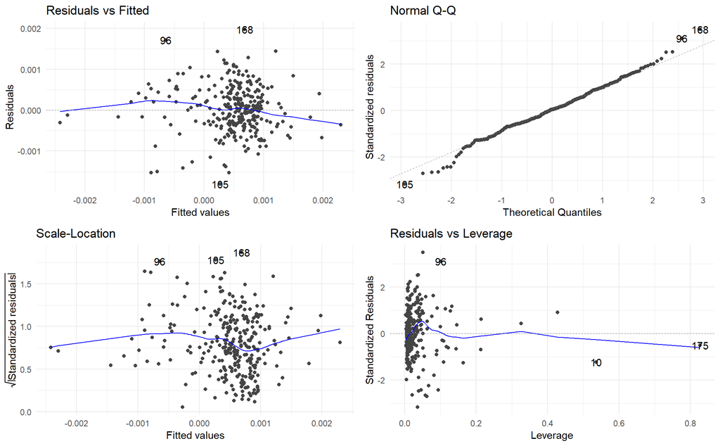

```r
autoplot(market_risk_price_lm)
```

Further solidifying this, I’ve included a histogram of the residuals to observe their shape. As seen, they appear to be reasonably normal.

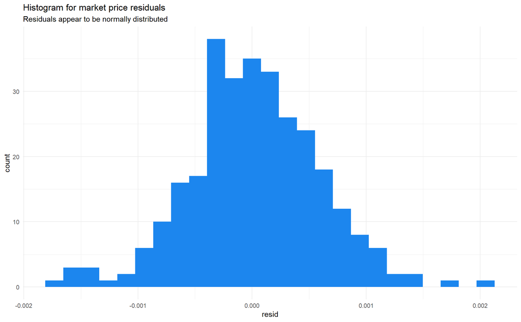

```r
market_risk_residuals <- data.frame(
  index = seq(1, nrow(market_betas), 1),
  resid = residuals(market_risk_price_lm)
) %>%
  mutate(stock = market_betas$Stock,
         portfolio_position = ifelse(resid > 0, "Long", "Short"))

market_risk_residuals %>%
  ggplot(aes(resid)) +
  geom_histogram(bins = 25, fill = "dodgerblue2") +
  labs(title = "Histogram for market price residuals",
       subtitle = "Residuals appear to be normally distributed")
```

In the previous step, I added variables to denote a long or short stock based on their residuals. Here, I’ve highlighted that for each bar.

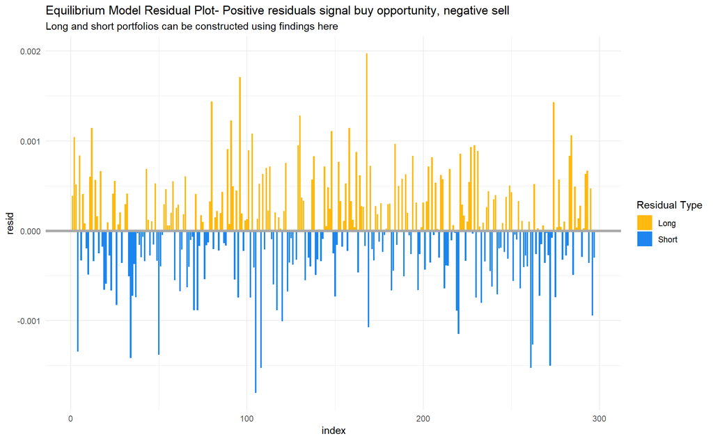

```r
market_risk_residuals %>%
  ggplot(aes(index, resid, fill = portfolio_position)) +
  geom_col() +
  scale_fill_manual(values = c("darkgoldenrod1", "dodgerblue2")) +
  geom_hline(yintercept = 0, size = 1.3, colour = "darkgray") +
  labs(title = "Equilibrium Model Residual Plot- Positive residuals signal buy opportunity, negative sell",
       subtitle = "Long and short portfolios can be constructed using findings here",
       fill = "Residual Type")
```